# Text mining - Bag of Words model and Text Visualisation on Cars Recall News

Jia Xin

6 October 2018

# Introduction

The code practice below shows the Bag of Words (BoW) approach for Text Mining using R. Bag of Words approached is used in this case study to quickly assess and visualise the large amount of text data we obtained from web scraping. From this excercise we can also understand the pros and cons of using BoW method.

Required packages to install for this source code.

```r
knitr::opts_chunk$set(echo = TRUE)

library(qdap)
library(tm)
library(dplyr)
library(wordcloud)
library(plotrix)
library(dendextend)
library(ggplot2)
library(ggthemes)
library(RWeka)


#for overcoming java error when running
#Sys.setenv(JAVA_HOME='C:\\Program Files\\Java\\jre1.8.0_181')
#library(rJava)
```

## Our Approach

Load files that are generated from web crawling. The text data we are going to analyse came form 2 major source, Cars.com and AutoBlog - wich boardcast news and provide details description of car models that are recalled. We will start off with analysis the header of news content from cars.com (Title.csv)

```r
knitr::opts_chunk$set(echo = TRUE)
Title <- read.csv(file="Title.csv", header=TRUE, sep=",")
names <- read.csv(file="names.csv", header=TRUE, sep=",")
Content <- read.csv(file="content.csv", header=TRUE, sep=",")
```

# Text and Data exploration

We will first analyse the data from Cars.com by using the bag of words approach. A corpus for this carscom dataset has been created and frequent term is plotted to observe which words are frequently used.

From the bar chart below; we observed that the word recall, alert etc. are commonly used in text. These words may not have useful values in this context thus one of of overcoming this issue is to normalise the freq. DO note that the data below has not yet been cleaned (and not lemmentise or has stop words removed).

```r
#perform bag of words - then visualise

title_text <- names$title
title_source <- VectorSource(title_text)
title_corpus <- VCorpus(title_source)
title_corpus
```

```
## <<VCorpus>>
## Metadata:  corpus specific: 0, document level (indexed): 0
## Content:  documents: 500
```

```r
title_corpus[[15]]
```

```
## <<PlainTextDocument>>
## Metadata:  7
## Content:  chars: 31
```

```r
# Print the content of the 15th tweet in title_corpus
title_corpus[[15]][1]
```

```
## $content
## [1] "2018 BMW 5 Series: Recall Alert"
```

```r
#str(title_corpus[[15]])
str(title_text)
```

```
##  Factor w/ 483 levels " 2013 Suzuki Kizashi, SX4: Recall Alert",..: 98 121 458 61 239 218 4 8 199 233 ...
```

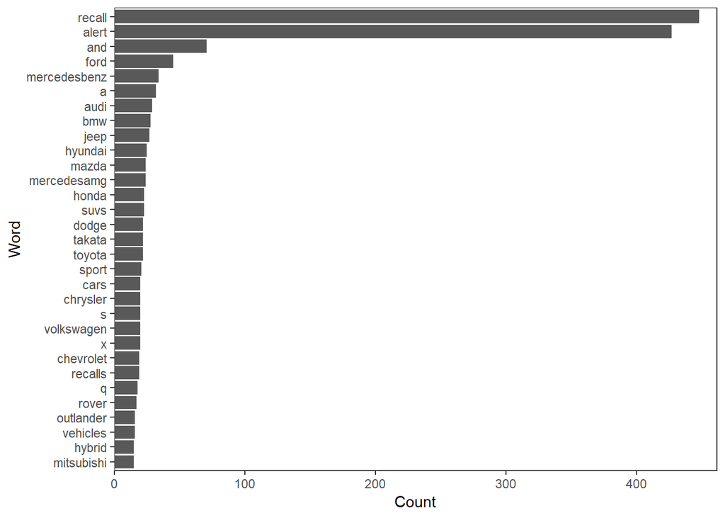

```r
#title_text <- as.character(title_text)

#Let's find the most frequent words in our text and see whether we should get rid of some
frequent_terms <- freq_terms(title_text, 30)
plot(frequent_terms)
```

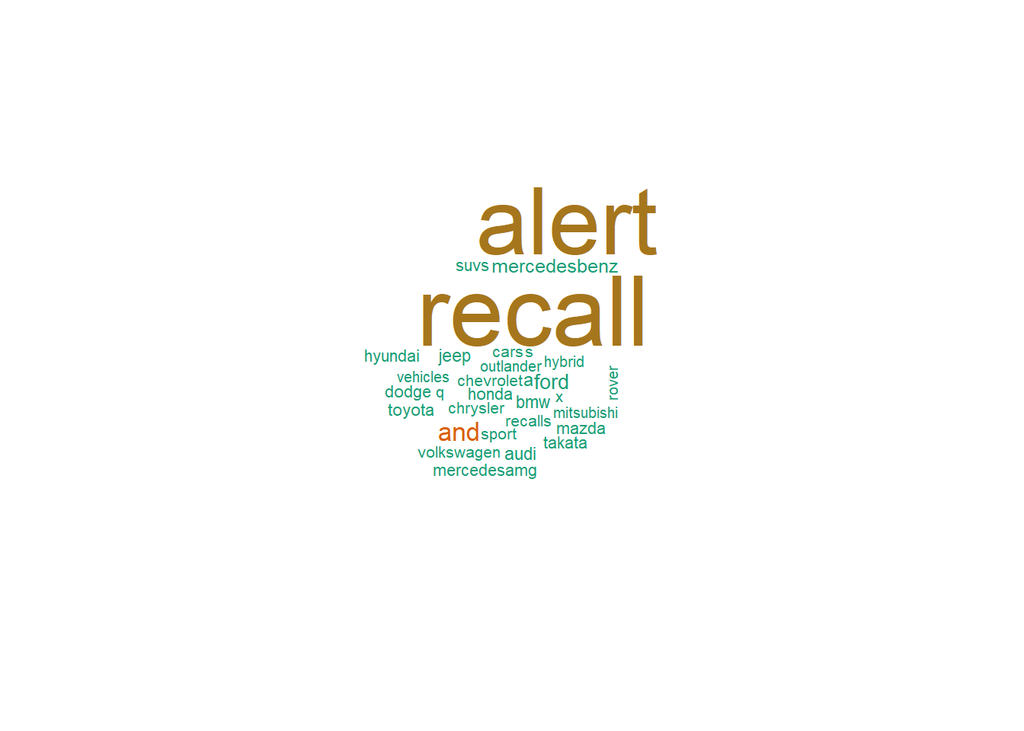

```r
# set word cloud
set.seed(123)
wordcloud(words = frequent_terms$WORD, freq=frequent_terms$FREQ, min.freq = 2, colors=brewer.pal(7, "Dark2"))
```

# Perform Data Cleaning

```r
# add stop words
all_stops <- c("a", "s ", "q", "x", "us", "recall", "recalls", "alert", "vehicles", "fix", "th", stopwords("en"))

# Well nothing stands out in particular, exepct ties and articles, so the standard wocabulary of stopwords
# in English will do just fine.
# Create the custom function that will be used to clean the corpus: clean_coupus
clean_corpus <- function(corpus){
  corpus <- tm_map(corpus, stripWhitespace)
  corpus <- tm_map(corpus, removePunctuation)
  corpus <- tm_map(corpus, content_transformer(tolower))
  corpus <- tm_map(corpus, removeWords, all_stops)
  corpus <- tm_map(corpus, removeNumbers)
  return(corpus)
}
# Apply your customized function to the tweet_corp: clean_corp
clean_corp <- clean_corpus(title_corpus)
# Print out a cleaned up tweet
clean_corp[[227]][1]
```

```
## $content
## [1] " bmw  series  "
```

```r
# Need to remove some of the stop words such as "recall", "alert", "and", "a" , "s" , "q" , etc
#making a term document matrix:
title_tdm <- TermDocumentMatrix(clean_corp, control = list(weighting = weightTfIdf))
title_tdm
```

```
## <<TermDocumentMatrix (terms: 524, documents: 500)>>
## Non-/sparse entries: 1528/260472
## Sparsity           : 99%
## Maximal term length: 15
## Weighting          : term frequency - inverse document frequency (normalized) (tf-idf)
```

```r
title_m <- as.matrix(title_tdm)
dim(title_m)
```

```
## [1] 524 500
```

```r
title_m[148:159, 10:22]
```

```
##             Docs
## Terms        10 11 12 13 14 15 16 17 18 19 20 21 22
##   entourage   0  0  0  0  0  0  0  0  0  0  0  0  0
##   envision    0  0  0  0  0  0  0  0  0  0  0  0  0
##   equinox     0  0  0  0  0  0  0  0  0  0  0  0  0
##   escape      0  0  0  0  0  0  0  0  0  0  0  0  0
##   eseries     0  0  0  0  0  0  0  0  0  0  0  0  0
##   even        0  0  0  0  0  0  0  0  0  0  0  0  0
##   evenflo     0  0  0  0  0  0  0  0  0  0  0  0  0
##   events      0  0  0  0  0  0  0  0  0  0  0  0  0
##   every       0  0  0  0  0  0  0  0  0  0  0  0  0
##   everything  0  0  0  0  0  0  0  0  0  0  0  0  0
##   evolution   0  0  0  0  0  0  0  0  0  0  0  0  0
##   evolve      0  0  0  0  0  0  0  0  0  0  0  0  0
```

```r
#dtm <- TermDocumentMatrix(docs)
title_m <- as.matrix(title_tdm)
v <- sort(rowSums(title_m),decreasing=TRUE)
d <- data.frame(word = names(v),freq=v)
head(d, 10)
```

```
##                      word     freq
## audi                 audi 89.72616
## bmw                   bmw 82.86166
## mazda               mazda 68.42764
## ford                 ford 51.34129
## mercedesbenz mercedesbenz 46.04069
## jeep                 jeep 41.51242
## toyota             toyota 41.28643
## chevrolet       chevrolet 40.10178
## mercedesamg   mercedesamg 39.35438
## hyundai           hyundai 38.68126
```

# Frequency Plot and Word Cloud

After performing cleaing in corpus and normalisation; we have obtained the most frequent occuring words in cars.com datset. From this data source we notice that top 3 car manufacturers being mentioned in recall news (from cars.com) are Audi, Bmw and Mazada.

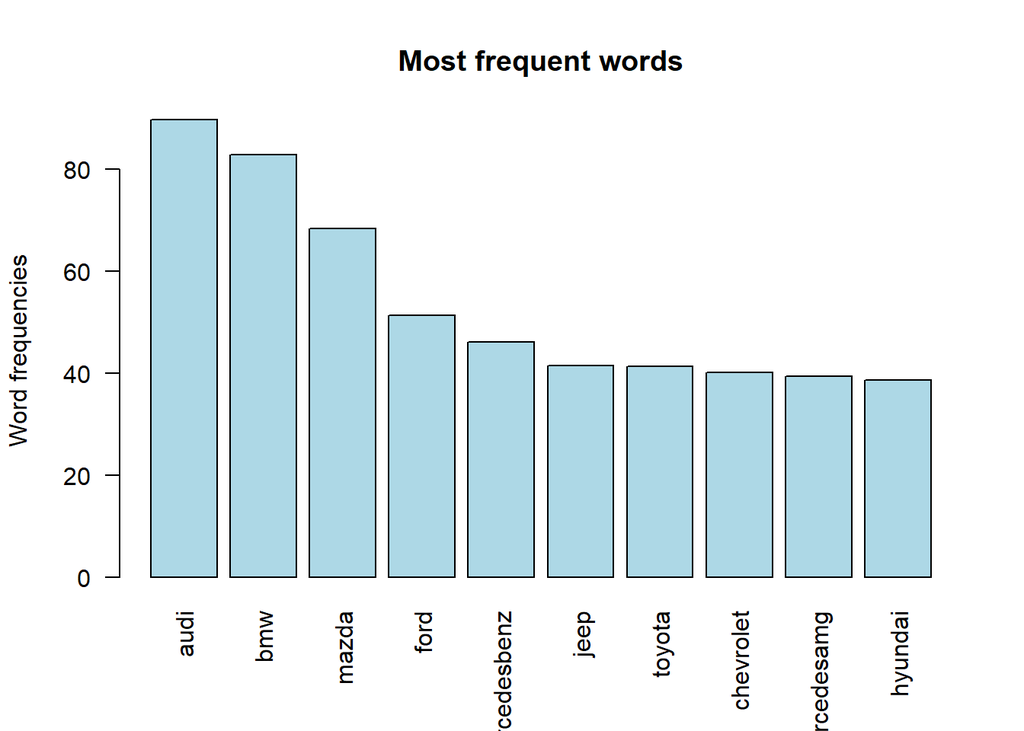

```r
barplot(d[1:10,]$freq, las = 2, names.arg = d[1:10,]$word,
        col ="lightblue", main ="Most frequent words",
        ylab = "Word frequencies")
```

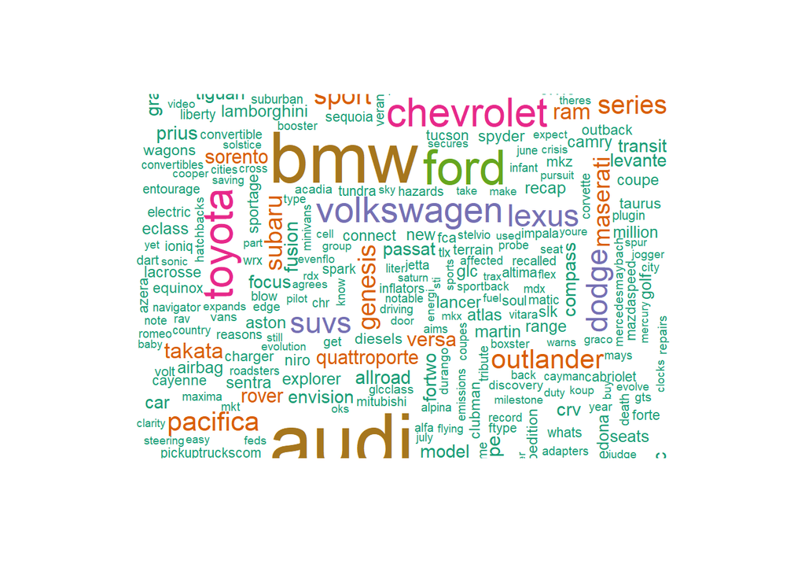

```r
wordcloud(words = d$word, freq=d$freq, min.freq = 2, colors=brewer.pal(7, "Dark2"))
```

# Understand Text Content of Carcom News

The web page content has already been loaed. The subsequent steps we will be performing the same cleaning and analysis on the web contents from cars.com. (content.csv) The content dataframe contains detailed articles about the model type and defects for defect etc.

```r
#perform bag of words - then visualise

str(Content)
```

```
## 'data.frame':    500 obs. of  2 variables:
##  $ content: Factor w/ 482 levels "","  As the owner of a Mercedes-AMG G65, you make your priorities eminently known. You appreciate the finer things"| __truncated__,..: 412 424 13 423 469 473 418 422 475 447 ...
##  $ date   : Factor w/ 294 levels "01/02/2018","01/05/2017",..: 51 41 41 32 269 269 232 232 220 220 ...
```

```r
nrow(Content)
```

```
## [1] 500
```

```r
content_text <- Content$content
content_source <- VectorSource(content_text)
content_corpus <- VCorpus(content_source)
content_corpus
```

```
## <<VCorpus>>
## Metadata:  corpus specific: 0, document level (indexed): 0
## Content:  documents: 500
```

```r
content_corpus[[15]]
```

```
## <<PlainTextDocument>>
## Metadata:  7
## Content:  chars: 1096
```

```r
# Print the content of the 15th tweet in title_corpus
content_corpus[[15]][1]
```

```
## $content
## [1] " Vehicles Affected: 12 model-year 2018 BMW 540d xDrive sedans\n The Problem: The crankshaft sensor may be equipped with incorrect firmware, possibly causing the vehile to stall and increasing the risk of a crash.\n The Fix: Dealers will replace the crankshaft sensor for free.\n What Owners S…
```

```r
str(content_corpus[[15]])
```

```
## List of 2
##  $ content: chr " Vehicles Affected: 12 model-year 2018 BMW 540d xDrive sedans\n The Problem: The crankshaft sensor may be equip"| __truncated__
##  $ meta   :List of 7
##   ..$ author       : chr(0)
##   ..$ datetimestamp: POSIXlt[1:1], format: "2018-10-13 23:33:47"
##   ..$ description  : chr(0)
##   ..$ heading      : chr(0)
##   ..$ id           : chr "15"
##   ..$ language     : chr "en"
##   ..$ origin       : chr(0)
##   ..- attr(*, "class")= chr "TextDocumentMeta"
##  - attr(*, "class")= chr [1:2] "PlainTextDocument" "TextDocument"
```

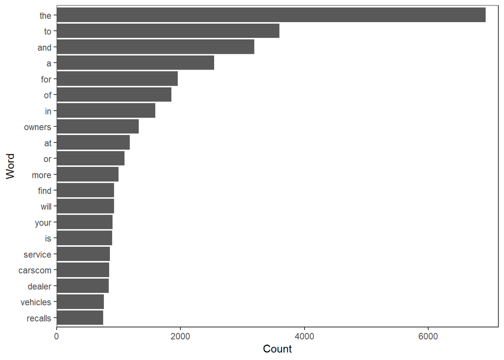

```r
content_text <- as.character(content_text)

#Let's find the most frequent words in our tweets_text and see whether we should get rid of some
frequent_terms1 <- freq_terms(content_text, 20)
plot(frequent_terms1)
```

```r
all_stops <- c("administration", "S", "vehiclesafety" , "group" , "announce","increases", "editors", "line", "dealers", "sponsored", "content", "said", "learn", "accept", "begin", "aware","increasing", "hotline", "editorial", "cars", "number", "approximately", "traffic","adminstrations", "vehicle", "carscom", "will", ", wwwsafercargov", "find", "dealer", "repair" ,"carscoms","free", "may", "problem", "affected", "can","a", "s ", "q", "x", "us", "immediately", "wwwsafercargov", "info", "recall", "recalls", "alert", "vehicles", "fix", "check" ,"owners", "service" ,"modelyear",
               "reviewers", "sales", "department", "departments", "notifying", "administrations", "manufactured", "automakers" ,"safety", "national", "trips", "source", "automotive", "website", "click","independent", "advertising" ,"policy","annouce", "call", "replace", "automaker", "news", "ownernotification", "model", "ethics", "longstanding", "dealership", "reviews", "dont", "department", "th", "visit", "go", "plant", "gle", "local", "need","gifts", "identification", "schedule", stopwords("en"))

# Well nothing stands out in particular, exepct ties and articles, so the standard wocabulary of stopwords
# in English will do just fine.
# Create the custom function that will be used to clean the corpus: clean_coupus
clean_corpus <- function(corpus){
  corpus <- tm_map(corpus, stripWhitespace)
  corpus <- tm_map(corpus, removePunctuation)
  corpus <- tm_map(corpus, content_transformer(tolower))
  corpus <- tm_map(corpus, removeWords, all_stops)
  corpus <- tm_map(corpus, removeNumbers)
  return(corpus)
}
# Apply your customized function to the tweet_corp: clean_corp
clean_corp1 <- clean_corpus(content_corpus)
# Print out a cleaned up tweet
clean_corp1[[227]][1]
```

```
## $content
## [1] "        bmw i i xdrive i xdrive i i xdrive  m luxury sedans   activehybrid  luxury sedans    d xdrive luxury sedans    rear reflex reflectors   reflect enough light making   less visible  others    risk   crash       rear reflex reflectors       bmw     july           highway                …
```

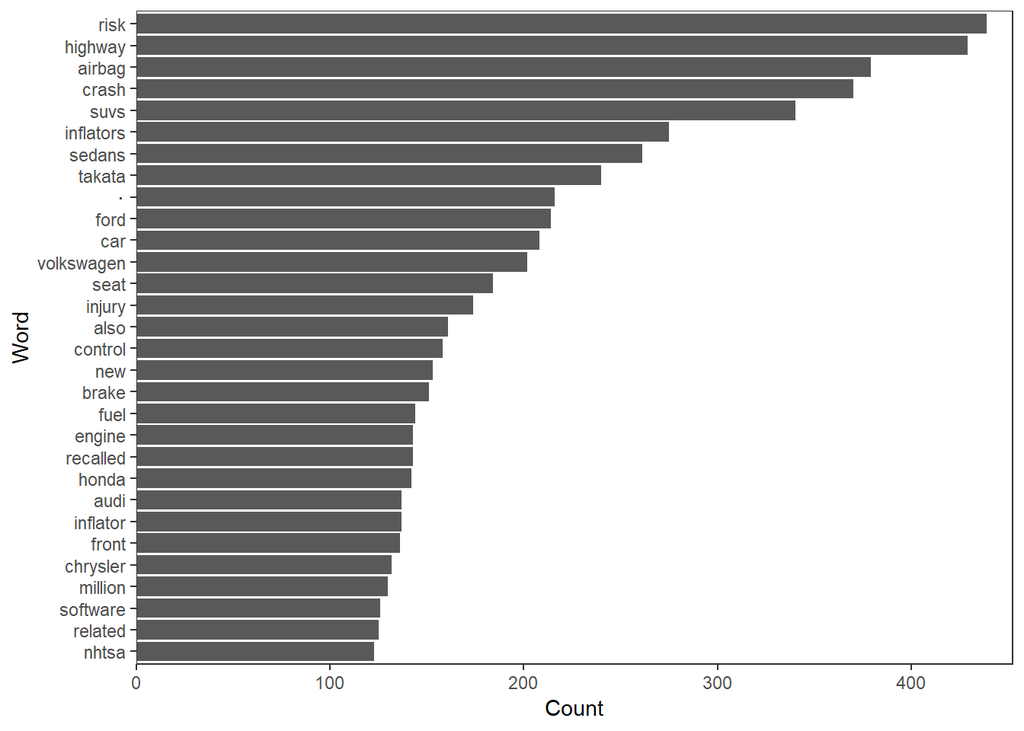

```r
#fast cleaning
content_text <- removePunctuation(content_text)
content_text <- removeNumbers(content_text)
content_text <- tolower(content_text)
content_text <- stripWhitespace(content_text)
# Print text without standard stop words
content_text <- removeWords(content_text, all_stops)

#after "fast and crude cleaning"
frequent_terms1 <- freq_terms(content_text, 30)
plot(frequent_terms1)
```

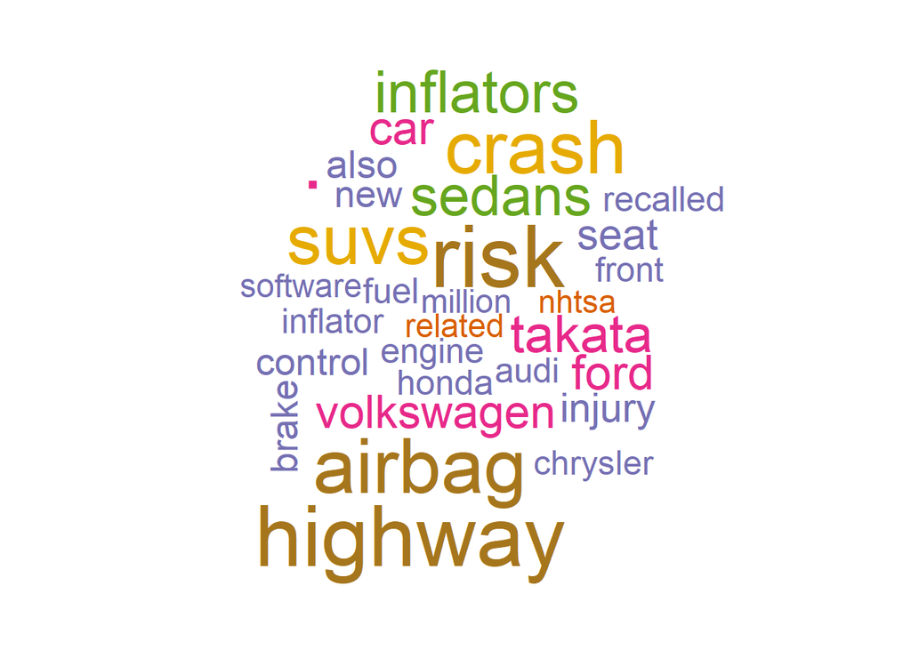

```r
set.seed(123)
wordcloud(words = frequent_terms1$WORD, freq=frequent_terms1$FREQ, min.freq = 2, colors=brewer.pal(7, "Dark2"))
```

```r
#--------------------------------------
# content --> Cleancorp1
#making a term document matrix:
content_tdm <- TermDocumentMatrix(clean_corp1, control = list(weighting = weightTfIdf))
content_tdm
```

```
## <<TermDocumentMatrix (terms: 5552, documents: 500)>>
## Non-/sparse entries: 26917/2749083
## Sparsity           : 99%
## Maximal term length: 27
## Weighting          : term frequency - inverse document frequency (normalized) (tf-idf)
```

```r
content_m <- as.matrix(content_tdm)
dim(content_m)
```

```
## [1] 5552  500
```

```r
content_m[148:159, 10:22]
```

```
##               Docs
## Terms          10 11 12 13 14 15 16         17 18 19 20 21 22
##   afterthought  0  0  0  0  0  0  0 0.03751374  0  0  0  0  0
##   afterward     0  0  0  0  0  0  0 0.00000000  0  0  0  0  0
##   age           0  0  0  0  0  0  0 0.00000000  0  0  0  0  0
##   agencies      0  0  0  0  0  0  0 0.00000000  0  0  0  0  0
##   agency        0  0  0  0  0  0  0 0.00000000  0  0  0  0  0
##   agencys       0  0  0  0  0  0  0 0.00000000  0  0  0  0  0
##   agent         0  0  0  0  0  0  0 0.00000000  0  0  0  0  0
##   aggregation   0  0  0  0  0  0  0 0.00000000  0  0  0  0  0
##   aggressive    0  0  0  0  0  0  0 0.00000000  0  0  0  0  0
##   aggressively  0  0  0  0  0  0  0 0.00000000  0  0  0  0  0
##   aging         0  0  0  0  0  0  0 0.00000000  0  0  0  0  0
##   ago           0  0  0  0  0  0  0 0.00000000  0  0  0  0  0
```

```r
v1 <- sort(rowSums(content_m),decreasing=TRUE)
d1 <- data.frame(word = names(v1),freq=v1)
head(d1, 10)
```

```
##            word      freq
## fuel       fuel 11.318707
## seat       seat  9.959556
## audi       audi  9.841551
## ford       ford  9.676657
## airbag   airbag  9.324380
## brake     brake  9.104961
## matic     matic  8.733096
## hyundai hyundai  8.676016
## bmw         bmw  8.660480
## engine   engine  8.611693
```

# Content Anaysis with Bar chart and word cloud

From here, we can observe that there are words like fuel, seat and brake which are more frequent but these point itself might not no or less meaning on its own. A good way to understand relationship between words is to tokenize into n-gram.

[figure not shown]

```r
barplot(d1[1:10,]$freq, las = 2, names.arg = d1[1:10,]$word,
        col ="lightgreen", main ="Most frequent words on news content",
        ylab = "Word frequencies")
```

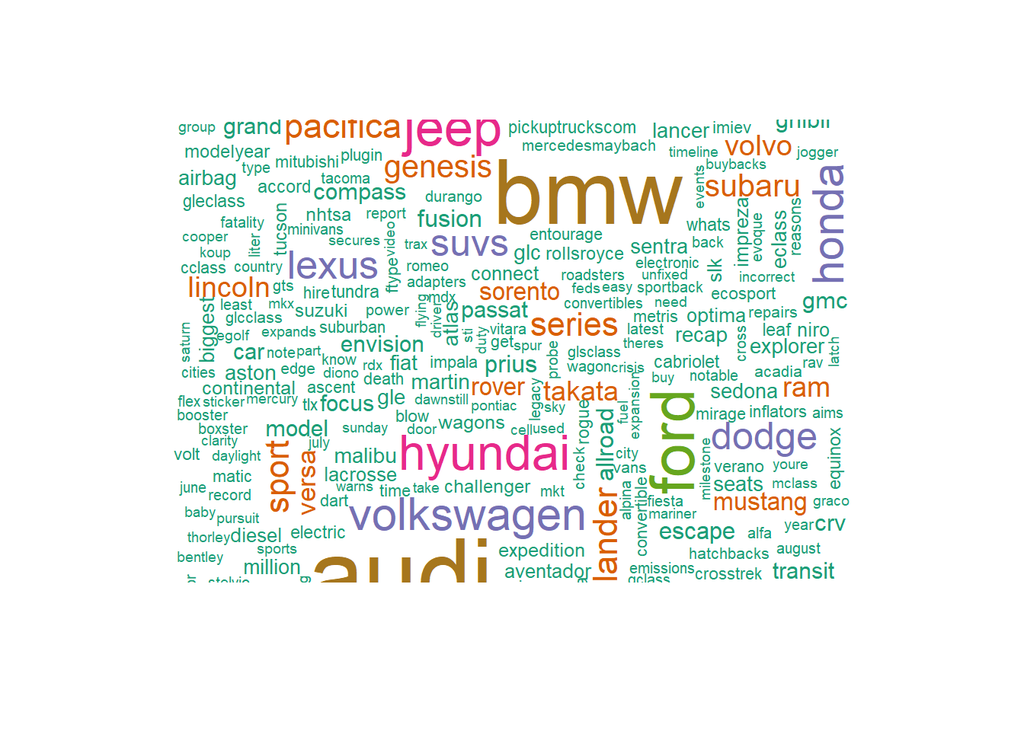

```r
wordcloud(words = d$word, freq=d$freq, min.freq = 2, colors=brewer.pal(7, "Dark2"))
```

# Tokenizing by n-gram

Bag of words model is a quick way to visualise and understand the context of large amount of text. However, it may not be well enough to understand the relationships between words.

The following steps we are going to explore using N-gram by tokenizing the words. By seeing how often word X is followed by word Y, we can then build a model of the relationships between them.

A Tokenizer function is created below for bigram and trigram.

```r
#tokeniser function: bigram
tokenizer <- function(x){
  NGramTokenizer(x, Weka_control(min =2, max = 2))
}

# Create bigram_dtm_m
bigram_dtm <- DocumentTermMatrix((clean_corp1), control = list(tokenizer=tokenizer))
bigram_dtm
```

```
## <<DocumentTermMatrix (documents: 500, terms: 27323)>>
## Non-/sparse entries: 36665/13624835
## Sparsity           : 100%
## Maximal term length: 36
## Weighting          : term frequency (tf)
```

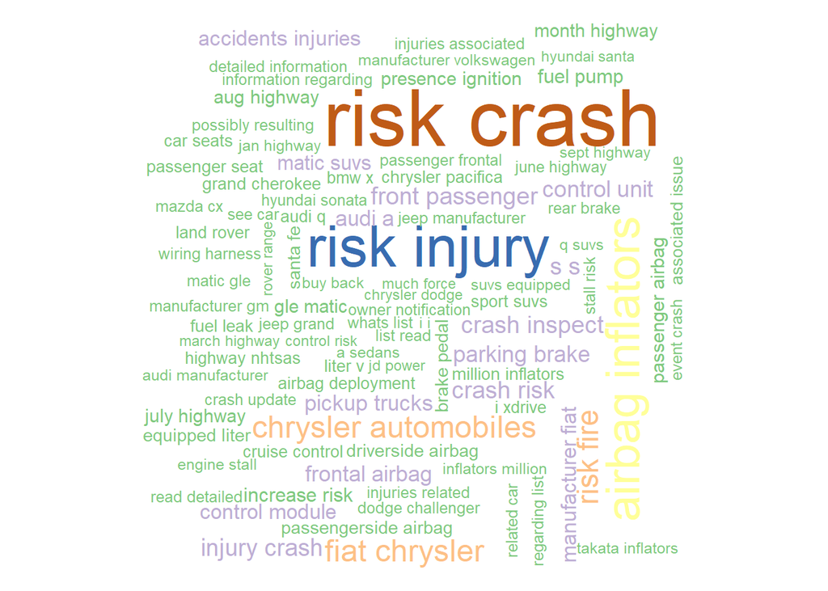

```r
bigram_dtm_m <- as.matrix(bigram_dtm)

# Create freq
freq <- colSums(bigram_dtm_m)

# Create bi_words
bi_words <- names(freq)

# Examine part of bi_words
#str_subset(bi_words, "^kia")

# Plot a wordcloud
wordcloud(bi_words, freq, max.words =100, min.freq = 2, colors=brewer.pal(7, "Accent"))
```

```r
# trigram

#tokeniser function: bigram
tokenizer <- function(x){
  NGramTokenizer(x, Weka_control(min =3, max = 3))
}

# Create bigram_dtm_m
trigram_dtm <- DocumentTermMatrix((clean_corp1), control = list(tokenizer=tokenizer))
trigram_dtm
```

```
## <<DocumentTermMatrix (documents: 500, terms: 34069)>>
## Non-/sparse entries: 38383/16996117
## Sparsity           : 100%
## Maximal term length: 48
## Weighting          : term frequency (tf)
```

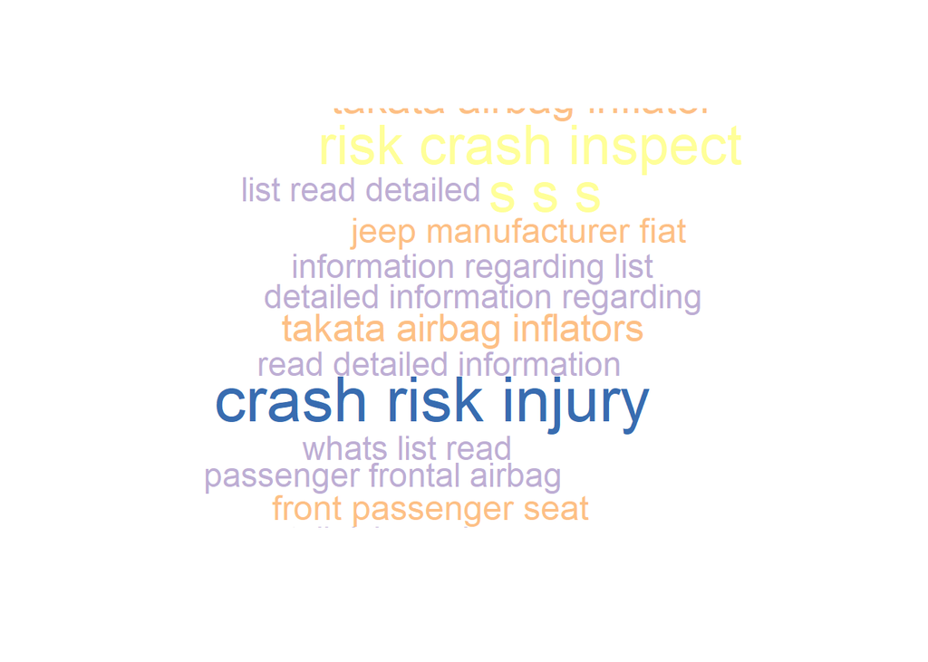

```r
trigram_dtm_m <- as.matrix(trigram_dtm)

# Create freq
freq2 <- colSums(trigram_dtm_m)

# Create bi_words
tri_words <- names(freq2)

# Plot a wordcloud
wordcloud(tri_words, freq2, max.words =20, min.freq = 2, colors=brewer.pal(7, "Accent"))
```

From here we can roughly induce that airbags are most frequently reported recall related defects and Takata airbag seem to be the highest occurence for Cars recall.

# Data Loading and cleaning Autoblog

Autoblog is another websource contains the recall and defects detailed from all the cars between 2016-2018. The contents have been transform into csv and is loaded (see below).

```r
#new data from autoblog dot com
Contents1 <- read.csv(file="content_1.csv", header=TRUE, sep=",")


#create new corpus
str(Contents1)
```

```
## 'data.frame':    1404 obs. of  2 variables:
##  $ title  : Factor w/ 1331 levels "\030Star Trek\031 actor's family settles with Fiat Chrysler over his death",..: 2 464 1257 15 356 1113 389 479 807 517 ...
##  $ content: Factor w/ 1331 levels "'Tis the season... for road salt. And with that, comes rust. And what does rust bring? Well, for Ford and Gener"| __truncated__,..: 298 677 1173 628 346 1208 373 427 1273 214 ...
```

```r
nrow(Contents1)
```

```
## [1] 1404
```

```r
title_text1 <- Contents1$title
title_source1 <- VectorSource(title_text1)
title_corpus1 <- VCorpus(title_source1)
title_corpus1
```

```
## <<VCorpus>>
## Metadata:  corpus specific: 0, document level (indexed): 0
## Content:  documents: 1404
```

```r
title_text1 <- as.character(title_text1)


all_stops <- c("administration", "S" , "group" , "announce","increases", "editors", "line", "dealers", "sponsored", "content", "said", "learn", "accept", "begin", "aware","increasing", "hotline", "editorial", "cars", "number", "approximately", "traffic","adminstrations", "vehicle", "carscom", "will", ", wwwsafercargov", "find", "dealer", "repair" ,"carscoms","free", "may", "problem", "affected", "can","a", "s ", "q", "x", "us", "immediately", "wwwsafercargov", "info", "recall", "recalls", "alert", "vehicles", "fix", "check" ,"owners", "service" ,"modelyear",
               "reviewers", "sales", "campaigns", "expands", "department","models", "million", "due", "annouces", "new", "two", "recalled", "departments", "k", "nearly", "gm" , "recalling", "m", "update" ,"notifying", "manufactured", "automakers" ,"safety", "national", "trips", "source", "automotive", "website", "click","independent", "advertising" ,"policy","annouce", "call", "replace", "automaker", "news", "ownernotification", "model", "ethics", "longstanding", "dealership", "reviews", "dont", "department", "th", "visit", "go", "plant", "gle", "local", "need","gifts", "identification", "schedule", stopwords("en"))


# Well nothing stands out in particular, exepct ties and articles, so the standard wocabulary of stopwords
# in English will do just fine.
# Create the custom function that will be used to clean the corpus: clean_coupus
clean_corpus2 <- function(corpus){
  corpus <- tm_map(corpus, stripWhitespace)
  corpus <- tm_map(corpus, removePunctuation)
  corpus <- tm_map(corpus, content_transformer(tolower))
  corpus <- tm_map(corpus, removeWords, all_stops)
  return(corpus)
}
# Apply your customized function to the tweet_corp: clean_corp
clean_corp2 <- clean_corpus(title_corpus1)
# Print out a cleaned up tweet
clean_corp2[[227]][1]
```

```
## $content
## [1] "  teslas   checks  pretty lofi"
```

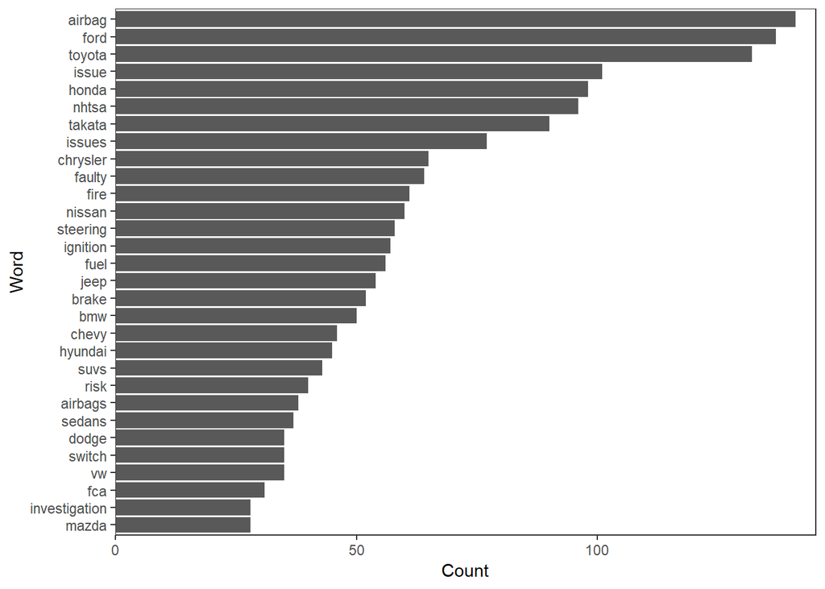

```r
#fast cleaning
title_text1 <- removePunctuation(title_text1)
title_text1 <- removeNumbers(title_text1)
title_text1 <- tolower(title_text1)
title1 <- stripWhitespace(title_text1)
# Print text without standard stop words
title_text1 <- removeWords(title_text1, all_stops)

#Let's find the most frequent words in our tweets_text and see whether we should get rid of some
frequent_terms2 <- freq_terms(title_text1, 30)
plot(frequent_terms2)
```

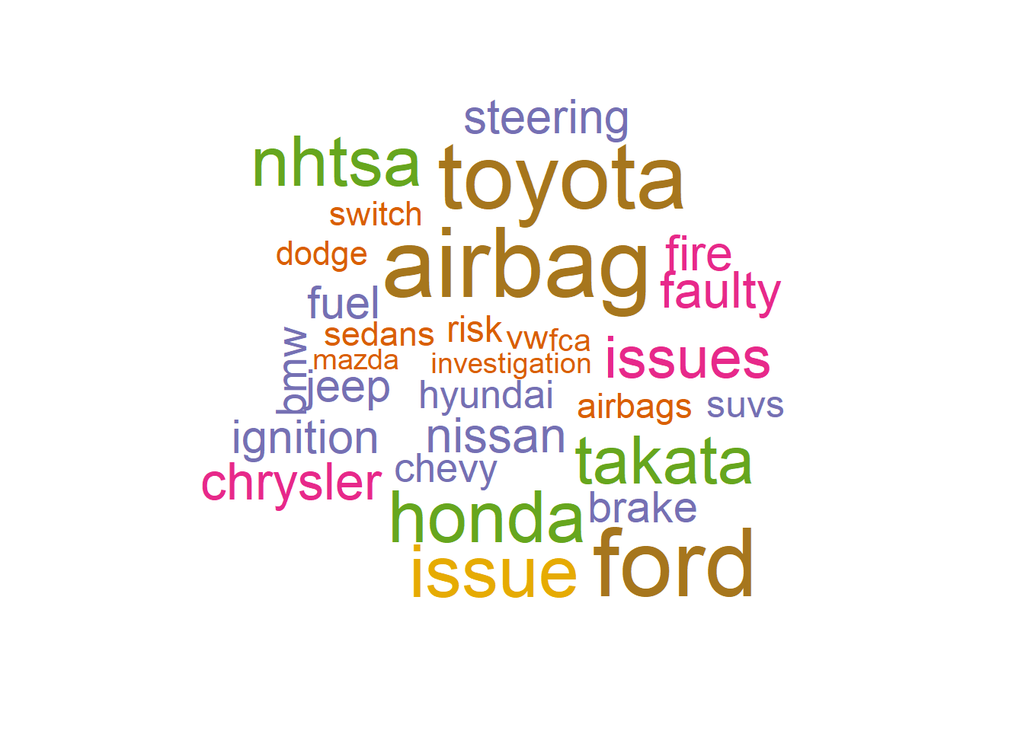

```r
set.seed(123)
wordcloud(words = frequent_terms2$WORD, freq=frequent_terms2$FREQ, min.freq = 2, colors=brewer.pal(7, "Dark2"))
```

```r
# looks like there could be some good work to deep further on this blog to understand what are are the defects about
```